# Founders Brewing Co.

Y.Leung, K.Richardson

February 23, 2019

## R Libraries

[output not shown]

[output not shown]

[output not shown]

## Introduction

Founders is the fastest growing brewery in the U.S. with 5.2 percent of 2017 sales growth coming from new markets. “Much of Founders’ success in 2017 can be attributed to All Day IPA, a 4.7 percent ABV session beer that now accounts for about 60 percent of the company’s total output. Sales of that beer were up 37 percent in 2017, and Stevens believes there’s still plenty of runway left”. https://www.brewbound.com/news/34-percent-founders-brewing-eyes-625000-barrels-2018.

Mike Stevens and Dave Engbers, owners of Founders Brewery presented Leung and Richardson Data Analytics Group with two data sets; beer.csv and breweries.csv. Our client would like us to conduct an analysis of the data and provide some insights.

## Import Files

```r
beers <- read.csv(file = 'C:\\Users\\Yat\\Documents\\MSDS\\MSDS 6306 Doing Data Science\\Case Study 1\\Beers.csv', header=TRUE, sep=",")
breweries<-read.csv(file = 'C:\\Users\\Yat\\Documents\\MSDS\\MSDS 6306 Doing Data Science\\Case Study 1\\Breweries.csv', header=TRUE, sep=",")
```

## Breweries Per State

```r
#List the brewery counts per state and convert into data frame
BreweryPerState<-table(breweries$State)
BreweryPerState<-data.frame(BreweryPerState)
#Rename the Header of BreweryPerState
colnames(BreweryPerState)[1]<-"State"
colnames(BreweryPerState)[2]<-"Brewery_Count"
#Arrange the State by brewery counts
BreweryPerState<-arrange(BreweryPerState, desc(Brewery_Count))
#Print the data frame as a table
print(tbl_df(BreweryPerState),n=51)
```

```
## # A tibble: 51 x 2
##    State Brewery_Count
##    <fct>         <int>
##  1 " CO"            47
##  2 " CA"            39
##  3 " MI"            32
##  4 " OR"            29
##  5 " TX"            28
##  6 " PA"            25
##  7 " MA"            23
##  8 " WA"            23
##  9 " IN"            22
## 10 " WI"            20
## 11 " NC"            19
## 12 " IL"            18
```

[output cut: 39 more lines]

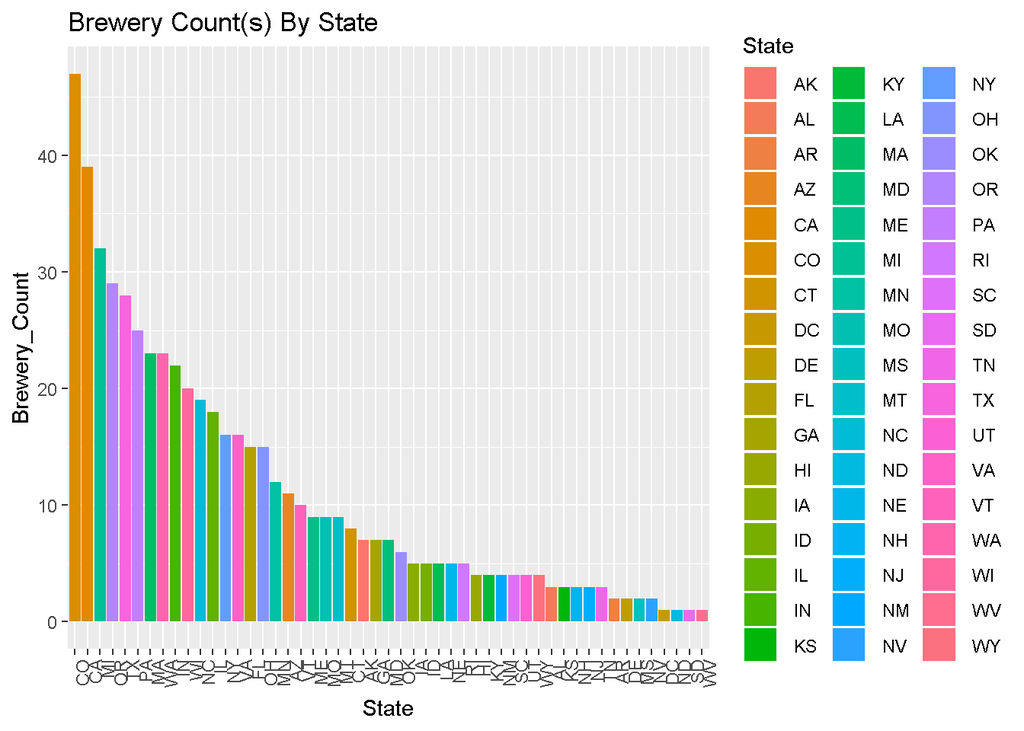

```r
#Plot Brewery Count Per State
ggplot(BreweryPerState, aes(y=Brewery_Count, x=reorder(State,-Brewery_Count),fill=State)) + geom_bar(stat = "identity")+ theme(axis.text.x = element_text(angle = 90, hjust = 1))+xlab("State")+ylab("Brewery_Count")+ggtitle("Brewery Count(s) By State")
```

A simple bar plot with the brewery count arranged in a descending order.

## Breweries Per State Map

```r
# map_data function to setup map
all_states <- map_data("state")
# changing statename to abbreviated name
all_states["State"] <- state2abbr(all_states$region)
# to get rid of spaces
BreweryPerState["State"] <- str_trim(BreweryPerState$State,"left")
BreweryPerState
```

```
##    State Brewery_Count
## 1     CO            47
## 2     CA            39
## 3     MI            32
## 4     OR            29
## 5     TX            28
## 6     PA            25
## 7     MA            23
## 8     WA            23
## 9     IN            22
## 10    WI            20
## 11    NC            19
## 12    IL            18
## 13    NY            16
## 14    VA            16
```

[output cut: 37 more lines]

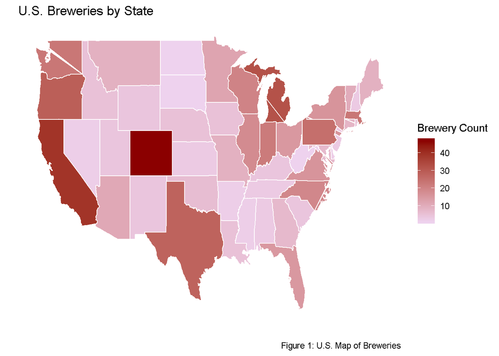

```r
# merging brewery data with map_data to generate U.s. map
Map.heat <- merge(all_states,BreweryPerState, by.x = c("State"), by.y = c("State"))
# creating varaible for ggplot
gp <- ggplot()
# customizing the u.s. map
gp <- gp + geom_polygon(data=Map.heat, aes(x=long, y=lat, group = State, fill=Map.heat$Brewery_Count),colour="white"
) + scale_fill_continuous(low = "thistle2", high = "darkred", guide="colorbar")
gp1 <- gp  + theme_bw()  + labs(fill = "Brewery Count",title = "U.S. Breweries by State", x="", y="",caption = "Figure 1: U.S. Map of Breweries")
gp2 <- gp1 + scale_y_continuous(breaks=c()) + scale_x_continuous(breaks=c()) + theme(panel.border = element_blank())
# output generated
gp2
```

As seen from the brewery map above, Colorado (47), California (39) and Michigan (32) are the top 3 states with the most breweries.

## Merge Breweries and Beers by brewery id

```r
#Merge the beers and breweries data frames by the brewery id
Brewery_Beer<-merge(beers, breweries,by.x = "Brewery_id", by.y = "Brew_ID")

#Rename the Header of the Beer Name and Brewery Name after merging
colnames(Brewery_Beer)[2]<-"Beer_Name"
colnames(Brewery_Beer)[8]<-"Brewery_Name"

#Print the first 6 rows of the Brewery_Beer data frame
Top6<-head(Brewery_Beer,6)
print(tbl_df(Top6),n=NULL,width = Inf)
```

```
## # A tibble: 6 x 10
##   Brewery_id Beer_Name     Beer_ID   ABV   IBU
##        <int> <fct>           <int> <dbl> <int>
## 1          1 Get Together     2692 0.045    50
## 2          1 Maggie's Leap    2691 0.049    26
## 3          1 Wall's End       2690 0.048    19
## 4          1 Pumpion          2689 0.06     38
## 5          1 Stronghold       2688 0.06     25
## 6          1 Parapet ESB      2687 0.056    47
##   Style                               Ounces Brewery_Name
##   <fct>                                <dbl> <fct>
## 1 American IPA                            16 "NorthGate Brewing "
## 2 Milk / Sweet Stout                      16 "NorthGate Brewing "
## 3 English Brown Ale                       16 "NorthGate Brewing "
## 4 Pumpkin Ale                             16 "NorthGate Brewing "
## 5 American Porter                         16 "NorthGate Brewing "
## 6 Extra Special / Strong Bitter (ESB)     16 "NorthGate Brewing "
##   City        State
##   <fct>       <fct>
## 1 Minneapolis " MN"
## 2 Minneapolis " MN"
## 3 Minneapolis " MN"
## 4 Minneapolis " MN"
## 5 Minneapolis " MN"
## 6 Minneapolis " MN"
```

```r
#Print the last 6 rows of the Brewery_Beer data frame
Bot6<-tail(Brewery_Beer,6)
print(tbl_df(Bot6),n=NULL,width = Inf)
```

```
## # A tibble: 6 x 10
##   Brewery_id Beer_Name                 Beer_ID   ABV   IBU
##        <int> <fct>                       <int> <dbl> <int>
## 1        556 Pilsner Ukiah                  98 0.055    NA
## 2        557 Heinnieweisse Weissebier       52 0.049    NA
## 3        557 Snapperhead IPA                51 0.068    NA
## 4        557 Moo Thunder Stout              50 0.049    NA
## 5        557 Porkslap Pale Ale              49 0.043    NA
## 6        558 Urban Wilderness Pale Ale      30 0.049    NA
##   Style                   Ounces Brewery_Name
##   <fct>                    <dbl> <fct>
## 1 German Pilsener             12 Ukiah Brewing Company
## 2 Hefeweizen                  12 Butternuts Beer and Ale
## 3 American IPA                12 Butternuts Beer and Ale
## 4 Milk / Sweet Stout          12 Butternuts Beer and Ale
## 5 American Pale Ale (APA)     12 Butternuts Beer and Ale
## 6 English Pale Ale            12 Sleeping Lady Brewing Company
##   City          State
##   <fct>         <fct>
## 1 Ukiah         " CA"
## 2 Garrattsville " NY"
## 3 Garrattsville " NY"
## 4 Garrattsville " NY"
## 5 Garrattsville " NY"
## 6 Anchorage     " AK"
```

After merging the 2 data sets, print the Top and Bottom 6 rows of data in the merged file to confirm and ensure the merged file correctness.

## Numbers of NA in each column

```r
#Count the number of times N/A appears in each column
NaPerCol<-Brewery_Beer %>%
  select(everything()) %>%
  summarise_all(funs(sum(is.na(.))))
#Print the NaPerCol data frame as a table
print(tbl_df(NaPerCol),n=NULL,width = Inf)
```

```
## # A tibble: 1 x 10
##   Brewery_id Beer_Name Beer_ID   ABV   IBU Style Ounces Brewery_Name  City
##        <int>     <int>   <int> <int> <int> <int>  <int>        <int> <int>
## 1          0         0       0    62  1005     0      0            0     0
##   State
##   <int>
## 1     0
```

```r
#Get total row counts, this is the same for all columns
totalRowCount<-nrow(Brewery_Beer)

#Percentage of time N/A appears in each column
PercentageNAperCol<-NaPerCol/totalRowCount*100
#Print the percent of NA per column as a table
print(tbl_df(PercentageNAperCol),n=NULL,width = Inf)
```

```
## # A tibble: 1 x 10
##   Brewery_id Beer_Name Beer_ID   ABV   IBU Style Ounces Brewery_Name  City
##        <dbl>     <dbl>   <dbl> <dbl> <dbl> <dbl>  <dbl>        <dbl> <dbl>
## 1          0         0       0  2.57  41.7     0      0            0     0
##   State
##   <dbl>
## 1     0
```

```r
#Summary Table of total NA counts and total Row counts per column
NaCountTable<-rbind(NaPerCol,totalRowCount)
#Make the name frame for NaCountTable
Variables<-c("N/A Counts","Total Counts")
#Combine Variables and NaCountTable
NaCountTable<-cbind(Variables,NaCountTable)
#Print the NaCountTable data frame as a table
print(tbl_df(NaCountTable),n=NULL,width = Inf)
```

```
## # A tibble: 2 x 11
##   Variables    Brewery_id Beer_Name Beer_ID   ABV   IBU Style Ounces
##   <fct>             <int>     <int>   <int> <int> <int> <int>  <int>
## 1 N/A Counts            0         0       0    62  1005     0      0
## 2 Total Counts       2410      2410    2410  2410  2410  2410   2410
##   Brewery_Name  City State
##          <int> <int> <int>
## 1            0     0     0
## 2         2410  2410  2410
```

The merged data set has 2410 rows of data, and by counting the numbers of missing values in each column, we would see that almost half the IBU values were missing (~42%). There was ~3% of ABV data missing but was not too detrimental in the analysis.

## Median Alcohol Content and IBU per state

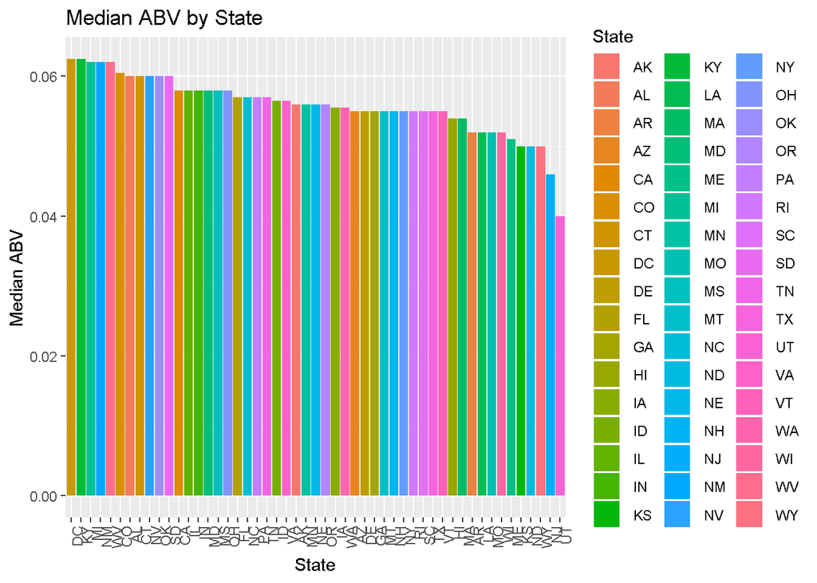

```r
#Calculate ABV and IBU medians
medianABV<-Brewery_Beer %>%  group_by(State) %>%  summarize(median_ABV = median(ABV, na.rm = TRUE))
medianIBU<-Brewery_Beer %>%  group_by(State) %>%  summarize(median_IBU = median(IBU, na.rm = TRUE))

#Remove all NA values from medianABV and medianIBU data frames
medianABV<-na.omit(medianABV)
medianIBU<-na.omit(medianIBU)

#Plot median ABV
#Reorder from highest to lowest
ggplot(medianABV, aes(y=median_ABV, x=reorder(State,-median_ABV),fill=State)) + geom_bar(stat = "identity")+ theme(axis.text.x = element_text(angle = 90, hjust = 1))+xlab("State")+ylab("Median ABV")+ggtitle("Median ABV by State")
```

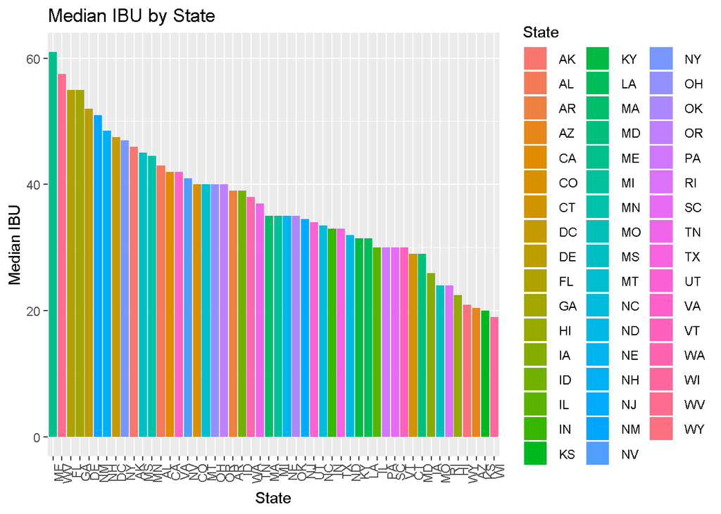

```r
#Plot median IBU
#Reorder from highest to lowest
ggplot(medianIBU, aes(y=median_IBU, x=reorder(State,-median_IBU),fill=State)) + geom_bar(stat = "identity")+ theme(axis.text.x = element_text(angle = 90, hjust = 1))+xlab("State")+ylab("Median IBU")+ggtitle("Median IBU by State")
```

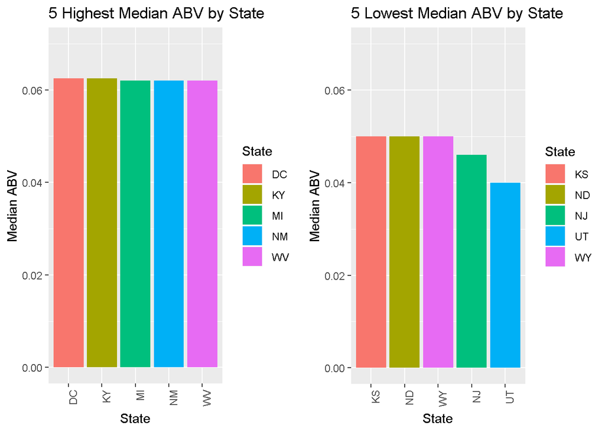

```r
#Plot Top and Bottom 5 median ABV
#Sort the medianABV by median_ABV
SortedMedABV<-arrange(medianABV, desc(median_ABV))
#Find the top 5 from the sortedMedABV df
Top5ABV<-head(SortedMedABV,5)
#Find the bottom 5 from the sortedMedABV df
Bot5ABV<-tail(SortedMedABV,5)

#Top 5 Median ABV plot
A<-ggplot(Top5ABV, aes(y=median_ABV, x=reorder(State,-median_ABV),fill=State)) + geom_bar(stat = "identity")+ theme(axis.text.x = element_text(angle = 90, hjust = 1))+xlab("State")+ylab("Median ABV")+ggtitle("5 Highest Median ABV by State")+ ylim(0,0.07)
#Bottom 5 Median ABV plot
B<-ggplot(Bot5ABV, aes(y=median_ABV, x=reorder(State,-median_ABV),fill=State)) + geom_bar(stat = "identity")+ theme(axis.text.x = element_text(angle = 90, hjust = 1))+xlab("State")+ylab("Median ABV")+ggtitle("5 Lowest Median ABV by State")+ ylim(0,0.07)
#(Side by side bar plots) for the Top and Bottom Median ABV
grid.arrange(A, B, nrow = 1)
```

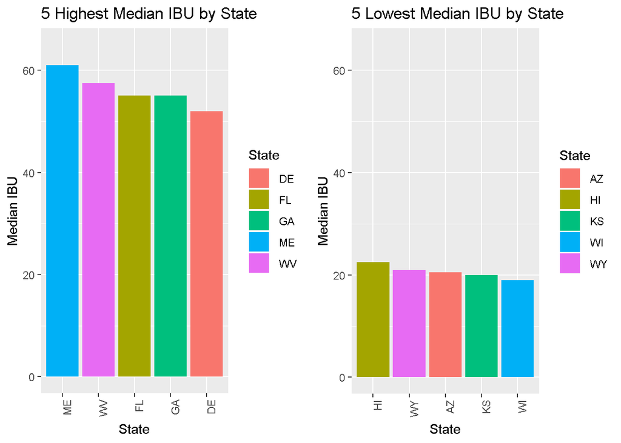

```r
#Plot Top and Bottom 5 median IBU
#Sort the medianIBU by median_IBU
SortedMedIBU<-arrange(medianIBU, desc(median_IBU))
#Find the top 5 from the sortedMedIBU df
Top5IBU<-head(SortedMedIBU,5)
#Find the bottom 5 from the sortedMedIBU df, SD was removed
Bot5IBU<-tail(SortedMedIBU,5)

# Top 5 Median IBU plot
C<-ggplot(Top5IBU, aes(y=median_IBU, x=reorder(State,-median_IBU),fill=State)) + geom_bar(stat = "identity")+ theme(axis.text.x = element_text(angle = 90, hjust = 1))+xlab("State")+ylab("Median IBU")+ggtitle("5 Highest Median IBU by State")+ ylim(0,65)
#Bottom 5 Median IBU plot
D<-ggplot(Bot5IBU, aes(y=median_IBU, x=reorder(State,-median_IBU),fill=State)) + geom_bar(stat = "identity")+ theme(axis.text.x = element_text(angle = 90, hjust = 1))+xlab("State")+ylab("Median IBU")+ggtitle("5 Lowest Median IBU by State")+ ylim(0,65)
#(Side by side bar plots) for the Top and Bottom Median IBU
grid.arrange(C,D, nrow = 1)
```

After calculating the median values of ABV and IBU, we invoked the na.omit function for each median calculation to ensure that all missing values were completely removed.

The median ABV and median IBU plots were computed and charted by state. We noticed that in the median IBU graph, the top 5 beers with the highest median IBUs came from east coast states (ME,WV,FL,GA and DE).

## State with highest ABV and highest IBU

```r
#Find the Highest ABV and returns the State and the ABV value
Brewery_Beer %>%  slice(which.max(ABV))%>%select(State,ABV)
```

```
##   State   ABV
## 1    CO 0.128
```

```r
#Find the Highest IBU and returns the State and the IBU value
Brewery_Beer %>%  slice(which.max(IBU))%>%select(State,IBU)
```

```
##   State IBU
## 1    OR 138
```

The state with the higest ABV beer was Colorado and the beer with the highest IBU came from Oregon.

## Summary Statistics of ABV

```r
#Summary Statistics of ABV
Brewery_Beer %>%select(ABV)%>%summary()
```

```
##       ABV
##  Min.   :0.00100
##  1st Qu.:0.05000
##  Median :0.05600
##  Mean   :0.05977
##  3rd Qu.:0.06700
##  Max.   :0.12800
##  NA's   :62
```

The summary statistics of ABV showed that the mean and median were roughly equal (~0.06) with the max ABV at 0.128 and the min ABV at 0.001. The 1st and 3rd quartile of the ABV are 0.050 and 0.067.

## IBU versus ABV relationship

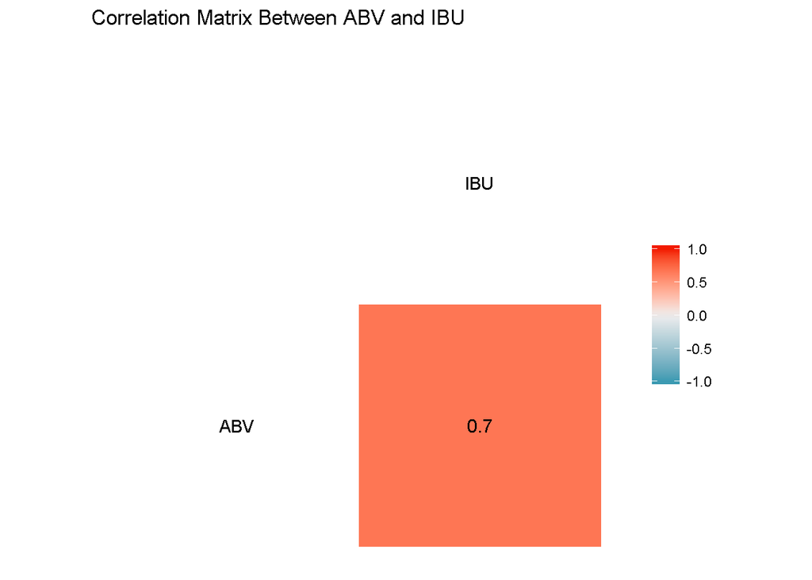

```r
#Correlation Matrix of IBU vs ABV
AbvIBU<-Brewery_Beer[,c(4,5)]
p<-ggcorr(AbvIBU,palette = "RdBu", label = TRUE)
p+ggtitle('Correlation Matrix Between ABV and IBU')
```

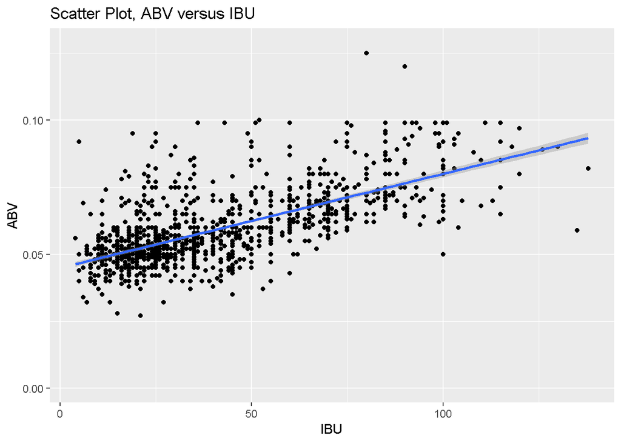

```r
#Scatter plot of IBU on x and ABV on y with regression line
ggplot(Brewery_Beer, aes(x=IBU, y=ABV))+geom_point()+geom_smooth(method="lm")+ggtitle("Scatter Plot, ABV versus IBU")
```

```r
#linear regression model between ABV and IBU
lm.ABV<-lm(ABV ~ IBU,Brewery_Beer)

#Summary Statistics of the linear regression model between ABV and IBU
summary(lm.ABV)
```

```
##
## Call:
## lm(formula = ABV ~ IBU, data = Brewery_Beer)
##
## Residuals:
##       Min        1Q    Median        3Q       Max
## -0.033288 -0.005946 -0.001595  0.004022  0.052006
##
## Coefficients:
##              Estimate Std. Error t value Pr(>|t|)
## (Intercept) 4.493e-02  5.177e-04   86.79   <2e-16 ***
## IBU         3.508e-04  1.036e-05   33.86   <2e-16 ***
## ---
## Signif. codes:  0 '***' 0.001 '**' 0.01 '*' 0.05 '.' 0.1 ' ' 1
##
## Residual standard error: 0.01007 on 1403 degrees of freedom
##   (1005 observations deleted due to missingness)
## Multiple R-squared:  0.4497, Adjusted R-squared:  0.4493
## F-statistic:  1147 on 1 and 1403 DF,  p-value: < 2.2e-16
```

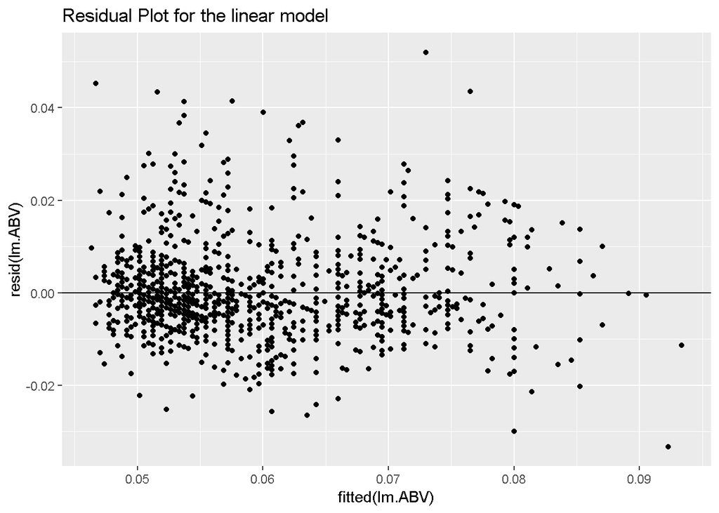

```r
#Residual Plot of the linear model
 qplot(fitted(lm.ABV), resid(lm.ABV))+geom_hline(yintercept=0)+ggtitle("Residual Plot for the linear model")
```

Plotting the ABV vs IBU, we would see that the data was clustered around 10-40 IBU (corresponding to 0.04 to 0.06 ABV). To determine the linear relationship, a regression analysis was performed with the following hypothesis. Null: Slope is equal to zero. Alternative: Slope is not equal to zero. Result: Reject Null given that the p-value is < 2.2e-16 (α=0.05) with the Adjusted R-squared 0.4493 (~45% of the variance of ABV can be explained by IBU)

## Conclusion

From the scatter plot as well as the residual plot, we saw that most of the data points were clustered around 10-40 IBU (corresponding to 0.04 to 0.06 ABV). Since the residual plot was not randomly scattered around 0, therefore the variance of the error terms may not be constant and could affect the validity of the proposed linear model.

## Youtube Link

https://youtu.be/RW-_SRXuM0k